# Terfenadine forced degradation data processing

Youzhong

2022-08-31

### Testing data availability

LC-MS/MS data and metadata of Terfenadine can be found at: https://zenodo.org/record/7018370#.YwscL3ZBw2w.

The pharmaceutical spectral database *Drug+* for spectra matching and unknown annotation can be found at: https://zenodo.org/record/7019893#.Yws1dHZBw2w

### Background of the dataset

Terfenadine is subjected to acid hydrolysis and oxidative stress against a baseline condition. The goal here is to profile and identify various degradation products of Terfenadine by setting stress conditions more severe than recommended storage, in order to further understand the underlying chemical mechanisms. Non-targeted profiling in DDA mode was conducted for samples at Day 0 (1 sample) and Day 7 (3 samples for 3 conditions) on an Orbitrap Fusion Lumos. Converted data files were submitted to MZMine for feature detection. Next, features representing different ion species of the same potential compound were put into a single feature. Fold change of each feature under different conditions was calculated. We then built a LC-MS/MS data processing pipeline in meRgeION that enables degradation product annotation by searching *Drug+* and mechanism understanding through FBMN.

### Input LC-MS/MS data description

DDA-mode data acquired on Orbitrap Fusion Lumos (.raw format) were converted to mzXML files using the software described at: https://ccms-ucsd.github.io/GNPSDocumentation/fileconversion/. Four files converted were Day 0, Day 7 control, Day 7 acidic, and Day 7 oxidative stress samples, respectively. Converted files were directly available for download:

```r
download.file("https://zenodo.org/record/7018370/files/FD_terfenadine_190218_MAS011_02.mzXML?download=1", "FD_terfenadine_190218_MAS011_02.mzXML")
download.file("https://zenodo.org/record/7018370/files/FD_terfenadine_190218_MAS011_03.mzXML?download=1", "FD_terfenadine_190218_MAS011_03.mzXML")
download.file("https://zenodo.org/record/7018370/files/FD_terfenadine_190218_MAS011_04.mzXML?download=1", "FD_terfenadine_190218_MAS011_04.mzXML")
download.file("https://zenodo.org/record/7018370/files/FD_terfenadine_190218_MAS011_05.mzXML?download=1", "FD_terfenadine_190218_MAS011_05.mzXML")
```

### Metadata description

Metadata table should contain target features labeled by a unique identifier. Here we include all MS1 features detected by MZMine and reduced by the meRgeION *process_mzmine* function. Fold change and relative quantification were calculated and included into the metadata table. Please download the metadata table prepared and put into the same R workspace:

```r
download.file("https://zenodo.org/record/7018370/files/molecular%20feature%20annotated%20terfenadine.csv?download=1", "molecular feature annotated.csv")
```

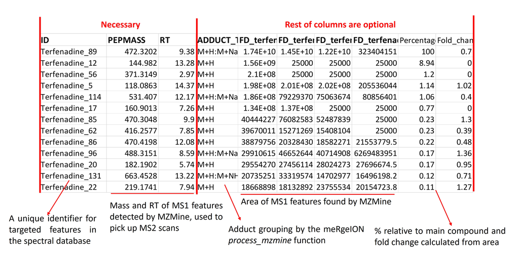

### Load MergeION

```r
library(MergeION)
```

### Target feature search in meRgeION

To extract MS/MS scan for each MS1 feature, meRgeION uses mass and retention time in the input metadata table. Here the Default smartION algorithm is used. Target feature search requires initial library (**input_library**, optional if the goal is to append new data into an existing database), input MS/MS file names (**lcms_files**), input metadata file name (**metadata_file**), polarity, extracted scan type (**mslevel**, MS1, MS2 or both), additional adducts (**add.adduct**, extracting additional adducts or not), processing algorithm, *m/z* and RT matching parameters (**params.search**), post-processing parameters for extracted scans (**params.ms.preprocessing**), and consensus scan generation parameters (**params.consensus**, combining scans of the same MS1 feature extracted from different files into a single consensus scan).

```r
help(library_generators) # More details about the parameters

input_library = NULL # We create a brand-new spectral database for this study
lcms_files = list.files(pattern = ".mzXML") # Make sure only the 4 mzXML files of Terfenadine are in the working directory
metadata_file = "molecular feature annotated.csv"
processing.algorithm = "Default"

# These parameters should reflect the mass and retention time deviation
params.search = list(mz_search = 0.01, ppm_search = 10, rt_search = 10, rt_gap = 30)

#  All MS/MS scans extracted are normalized to the highest peak, only top 200 most intense peaks were kept. An intensity baseline of 25000 was applied - here it reflects the noise level of Orbitrap instruments
params.ms.preprocessing = list(normalized = TRUE, baseline = 25000, relative = 0, max_peaks = 200, recalibration = 0)

# MS/MS scans of the same MS1 feature were extracted from different files,they are now combined to generate an fragment-rich consensus spectrum. Setting "consensus_method = consensus" kept fragments detected in all spectral records. A consensus window is applied to merge product ions with similar m/z values.
params.consensus = list(consensus = TRUE, consensus_method = "consensus", consensus_window = 0.01)

# We could now run target feature search and consensus spectrum generation:

library1 = library_generator(input_library, lcms_files, metadata_file,
polarity = "Positive", mslevel = 2, add.adduct = FALSE, processing.algorithm, params.search, params.ms.preprocessing, params.consensus)
```

### Library summary and lookup

The output **library1** is a list of three elements: *complete*, *consensus* and *network*. At this stage, only *complete* (scans extracted from all 4 DDA files) and *consensus* (one consensus spectrum per input feature) were generated. It is possible to create a summary of the spectral collection:

```r
library_reporter(library1)
```

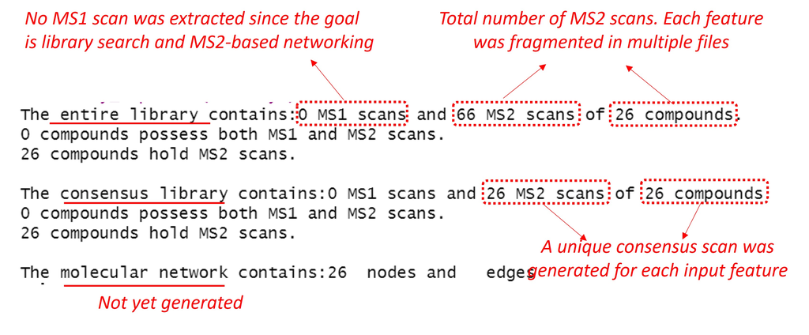

It is possible to look up the spectral database based on a vector of feature IDs or query conditions. The syntax of each query expression must be **condition = value**, while **condition** must match with column name of the input metadata. Spectral records extracted must fit all query conditions provided by user. The output is a filtered library containing both *complete* and *consensus*.

```r
# Extracting spectral records of parent compound based on its ID (if known by user)

query_result = library_query(input_library = library1, query_ids = "Terfenadine_89")

# Extracting spectral records of parent compound based on its precursor mass (PEPMASS) and retention time (RT)

query_result = library_query(input_library = library1, query_expression = c("PEPMASS = 472.3202", "RT = 9.4"))

# Print results:

library_reporter(query_result)

print(query_result$complete$metadata) # In total 4 scans of the parent compounds are extracted

print(query_result$consensus$metadata) # 1 consensus scan was found for the parent compound

# Extracting spectral records of feature for which M+H, M+Na and M+K adducts are detected

query_result = library_query(input_library = library1, query_expression = "ADDUCT_TYPE = M+H:M+Na:M+K")

library_reporter(query_result) # 4 features are detected with M+H, M+Na and M+K adducts

print(query_result$consensus$metadata$ID) # including Terfenadine_89 - the parent drug
```

### Searching against an existing spectral library

To annotate the extracted MS/MS scans in the forced degradation study, we search them against *Drug+*, a pharmaceutical MS/MS spectral library built by our team, currently available in ESI+ mode only:

```r
download.file("https://zenodo.org/record/7057435/files/lib_drug_plus_matrix.RData?download=1", "lib_drug_plus_matrix.RData") # Download Drug+ as a library object
load("lib_drug_plus_matrix.RData") # Load Drug+ as object lib_123_matrix into R environment
```

We first search the consensus MS/MS spectrum of the parent drug against *Drug+*

```r
# Extracting spectral records of parent compound based on RT and mass:

query_result = library_query(input_library = library1, query_expression = c("PEPMASS = 472.3202", "RT = 9.4"))
query_sp = query_result$consensus$sp[[1]] # Query_sp is a two-column matrix m/z, intensity of the parent compound consensus spectrum
query_mz = 472.3202 # Precursor mass of Terfenadine

# Setting up spectral library search parameters, first EXACT search:

params.query.sp = list(prec_mz = query_mz, use_prec = T, polarity = "Positive", method = "Cosine", min_frag_match = 6, min_score = 0, reaction_type = "Metabolic")

search_result = library_query(input_library = lib_123_matrix, query_spectrum = query_sp, params.query.sp = params.query.sp)
id_matched = search_result$consensus$metadata$ID[1]

library_visualizer(lib_123_matrix, id = id_matched, query_spectrum = query_sp)
```

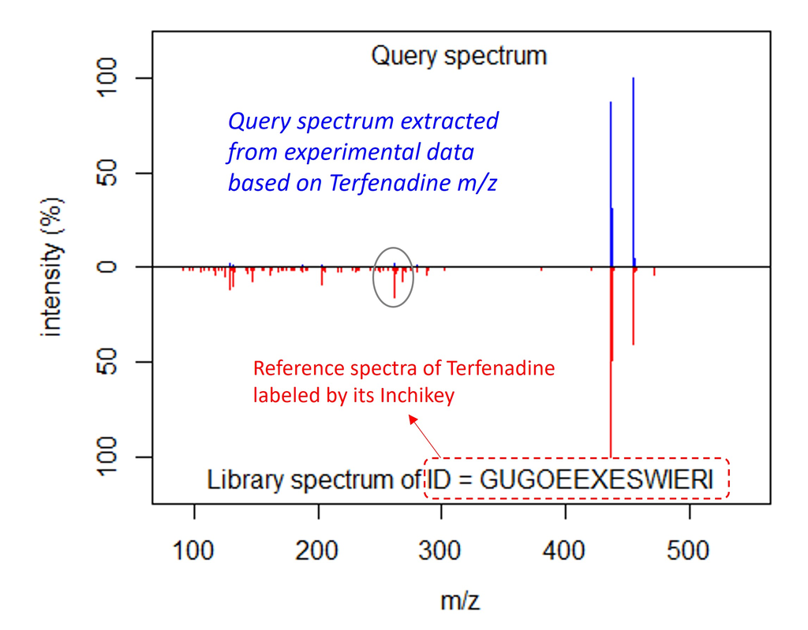

```r
# We now test analog search (by setting use_prec = F), this time using F1 as spectral similarity metrics. The goal is to find compounds with similar structures but different masses.

params.query.sp = list(prec_mz = query_mz, use_prec = F, polarity = "Positive", method = "F1", min_frag_match = 6, min_score = 0, reaction_type = "Metabolic")

search_result = library_query(input_library = lib_123_matrix, query_spectrum = query_sp, params.query.sp = params.query.sp)

ids_matched = search_result$consensus$metadata$ID
scores_matched = search_result$consensus$metadata$SCORE_MERGEION

# The top candidate is still Terfenadine based on InchiKey, the gives us extra structure confirmation:

print(ids_matched[1])

# Other candidates found and their scoring

print(ids_matched[2:4])
print(scores_matched[2:4])

#
```